# Project Oakland: Consumer Edge Data Summary

Max Kagan

2026-01-12

# Executive Summary

**Key Use Case for Project Oakland:** This data provides brand-level consumer spending as a potential **dependent variable** to measure whether employee-consumer partisan alignment affects actual purchasing behavior.

## Key Metrics Available

| Metric | Description |
| --- | --- |
| `SPEND_AMOUNT` | Total consumer spending ($) |
| `TRANS_COUNT` | Number of transactions |
| `INDIVIDUAL_COUNT` | Count of unique consumers |
| `YA_*` columns | Year-over-year comparisons |

## Geographic Granularity

- **TOTAL_US**: National aggregates
- **CENSUS_REGION**: 4 regions (Northeast, Midwest, South, West)
- **CENSUS_DIVISION**: 9 divisions
- **STATE**: 50 states + DC
- **CSA**: Combined Statistical Areas (metro regions)

# 1. Data Loading

```r
data_dir <- "/global/scratch/users/maxkagan/01_foot_traffic_location/consumer_edge_data_2026-01-12/brand-and-geography-cohort-breakout-usa-1"

files <- list.files(data_dir, pattern = "\\.csv\\.gz$", full.names = TRUE)
n_total_files <- length(files)

dt <- rbindlist(lapply(files, fread), fill = TRUE)

n_rows_sample <- nrow(dt)
n_cols <- ncol(dt)
```

**Data Source:** /global/scratch/users/maxkagan/01_foot_traffic_location/consumer_edge_data_2026-01-12/brand-and-geography-cohort-breakout-usa-1

- **Total files loaded:** 64
- **Total rows:** 116,850,468
- **Columns:** 18

# 2. Data Structure & Quality

## 2.1 Column Inventory

```r
col_info <- data.frame(
  Column = names(dt),
  Type = sapply(dt, function(x) class(x)[1]),
  NonMissing = sapply(dt, function(x) {
    if (is.character(x)) sum(!is.na(x) & x != "") else sum(!is.na(x))
  }),
  PctComplete = sapply(dt, function(x) {
    if (is.character(x)) mean(!is.na(x) & x != "") * 100 else mean(!is.na(x)) * 100
  })
)

col_info %>%
  mutate(
    NonMissing = format(NonMissing, big.mark = ","),
    PctComplete = paste0(round(PctComplete, 1), "%")
  ) %>%
  kable(caption = "Column Inventory", row.names = FALSE) %>%
  kable_styling(bootstrap_options = c("striped", "hover"), full_width = FALSE)
```

Column Inventory

| Column | Type | NonMissing | PctComplete |
| --- | --- | --- | --- |
| BRAND_ID | integer | 116,850,468 | 100% |
| BRAND_NAME | character | 116,850,468 | 100% |
| GEO | character | 116,850,468 | 100% |
| GEO_TYPE | character | 116,850,468 | 100% |
| INDIVIDUAL_COUNT | numeric | 116,850,468 | 100% |
| PERIOD | character | 116,850,468 | 100% |
| PERIOD_END_DT | IDate | 116,850,468 | 100% |
| PERIOD_START_DT | IDate | 116,850,468 | 100% |
| PERIOD_TYPE | character | 116,850,468 | 100% |
| SPEND_AMOUNT | numeric | 116,850,468 | 100% |
| TRANS_COUNT | numeric | 116,850,468 | 100% |
| VERSION | IDate | 116,850,468 | 100% |
| YA_INDIVIDUAL_COUNT | numeric | 62,875,751 | 53.8% |
| YA_PERIOD | character | 74,952,293 | 64.1% |
| YA_PERIOD_END_DT | IDate | 74,952,293 | 64.1% |
| YA_PERIOD_START_DT | IDate | 74,952,293 | 64.1% |
| YA_SPEND_AMOUNT | numeric | 62,875,751 | 53.8% |
| YA_TRANS_COUNT | numeric | 62,875,751 | 53.8% |

## 2.2 Sample Data Preview

```r
dt[1:5, .(BRAND_ID, BRAND_NAME, GEO, GEO_TYPE, PERIOD, SPEND_AMOUNT, TRANS_COUNT)] %>%
  kable(caption = "Sample Rows") %>%
  kable_styling(bootstrap_options = c("striped", "hover"), full_width = FALSE)
```

Sample Rows

| BRAND_ID | BRAND_NAME | GEO | GEO_TYPE | PERIOD | SPEND_AMOUNT | TRANS_COUNT |
| --- | --- | --- | --- | --- | --- | --- |
| 29978 | BLANKA | Minneapolis-St. Paul, MN-WI | CSA | 2025Q2 | 349.84 | 0.70 |
| 12240 | PRICE CHOPPER | Outside CSA | CSA | 2025Q2 | 1904758.27 | 36148.88 |
| 12346 | RENAISSANCE HOTELS | Myrtle Beach-Conway, SC-NC | CSA | 2025Q2 | 3550.06 | 17.88 |
| 32064 | X.AI | Washington-Baltimore-Arlington, DC-MD-VA-WV-PA | CSA | 2025Q2 | 1026.83 | 15.57 |
| 24480 | BROWNSTONE RESEARCH | AZ | STATE | 2025Q2 | 1792.14 | 9.37 |

## 2.3 Period Types Available

```r
period_summary <- dt[, .(
  N_Rows = .N,
  N_Brands = uniqueN(BRAND_ID),
  Total_Spend = sum(SPEND_AMOUNT, na.rm = TRUE)
), by = PERIOD_TYPE][order(-N_Rows)]

period_summary %>%
  mutate(
    N_Rows = format(N_Rows, big.mark = ","),
    N_Brands = format(N_Brands, big.mark = ","),
    Total_Spend = paste0("$", format(round(Total_Spend / 1e9, 2), big.mark = ","), "B")
  ) %>%
  kable(caption = "Data by Period Type") %>%
  kable_styling(bootstrap_options = c("striped", "hover"), full_width = FALSE)
```

Data by Period Type

| PERIOD_TYPE | N_Rows | N_Brands | Total_Spend |
| --- | --- | --- | --- |
| MONTH | 29,610,227 | 12,666 | $893.48B |
| DISCRETE_35_DAY | 27,869,210 | 12,681 | $936.99B |
| DISCRETE_91_DAY | 12,749,882 | 12,669 | $914.04B |
| CAL_QTR | 11,754,952 | 12,654 | $841.13B |
| CAL_QTR_JAN | 11,722,789 | 12,626 | $841.80B |
| CAL_QTR_FEB | 11,688,724 | 12,615 | $840.79B |
| DISCRETE_182_DAY | 7,298,355 | 12,669 | $914.04B |
| DISCRETE_364_DAY | 4,156,329 | 12,669 | $914.04B |

## 2.4 Geographic Coverage

```r
geo_summary <- dt[, .(
  N_Rows = .N,
  N_Unique_Geos = uniqueN(GEO),
  Total_Spend = sum(SPEND_AMOUNT, na.rm = TRUE)
), by = GEO_TYPE][order(-Total_Spend)]

geo_summary %>%
  mutate(
    N_Rows = format(N_Rows, big.mark = ","),
    N_Unique_Geos = format(N_Unique_Geos, big.mark = ","),
    Total_Spend = paste0("$", format(round(Total_Spend / 1e9, 2), big.mark = ","), "B")
  ) %>%
  kable(caption = "Data by Geography Type") %>%
  kable_styling(bootstrap_options = c("striped", "hover"), full_width = FALSE)
```

Data by Geography Type

| GEO_TYPE | N_Rows | N_Unique_Geos | Total_Spend |
| --- | --- | --- | --- |
| STATE | 35,087,376 | 51 | $1,419.26B |
| CENSUS_DIVISION | 9,437,214 | 9 | $1,419.26B |
| TOTAL_US | 1,368,618 | 1 | $1,419.26B |
| CENSUS_REGION | 4,729,653 | 4 | $1,419.26B |
| CSA | 66,227,607 | 173 | $1,419.26B |

## 2.5 Date Range

```r
if (!inherits(dt$PERIOD_START_DT, "Date")) {
  dt[, PERIOD_START_DT := as.Date(PERIOD_START_DT)]
}
if (!inherits(dt$PERIOD_END_DT, "Date")) {
  dt[, PERIOD_END_DT := as.Date(PERIOD_END_DT)]
}

date_range <- dt[, .(
  Min_Date = min(PERIOD_START_DT, na.rm = TRUE),
  Max_Date = max(PERIOD_END_DT, na.rm = TRUE)
)]

cat("Date range:", as.character(date_range$Min_Date), "to", as.character(date_range$Max_Date))
```

```
## Date range: 2022-09-05 to 2025-09-28
```

# 3. Brand-Level Analysis

## 3.1 Brand Universe

```r
n_brands <- uniqueN(dt$BRAND_ID)
n_brand_names <- uniqueN(dt$BRAND_NAME)

cat("Unique BRAND_IDs:", format(n_brands, big.mark = ","), "\n")
```

```
## Unique BRAND_IDs: 12,681
```

```r
cat("Unique BRAND_NAMEs:", format(n_brand_names, big.mark = ","))
```

```
## Unique BRAND_NAMEs: 12,681
```

## 3.2 Top 50 Brands by Total Spend

```r
brand_totals <- dt[GEO_TYPE == "TOTAL_US" & PERIOD_TYPE == "MONTH", .(
  Total_Spend = sum(SPEND_AMOUNT, na.rm = TRUE),
  Total_Trans = sum(TRANS_COUNT, na.rm = TRUE),
  Total_Individuals = sum(INDIVIDUAL_COUNT, na.rm = TRUE),
  N_Periods = uniqueN(PERIOD)
), by = .(BRAND_ID, BRAND_NAME)][order(-Total_Spend)]

top_50 <- brand_totals[1:50]

top_50 %>%
  mutate(
    Total_Spend = paste0("$", format(round(Total_Spend / 1e9, 2), big.mark = ","), "B"),
    Total_Trans = format(Total_Trans, big.mark = ","),
    Total_Individuals = format(Total_Individuals, big.mark = ",")
  ) %>%
  select(BRAND_NAME, Total_Spend, Total_Trans, N_Periods) %>%
  kable(caption = "Top 50 Brands by Total Spend (National, Monthly Data)") %>%
  kable_styling(bootstrap_options = c("striped", "hover"), full_width = FALSE) %>%
  scroll_box(height = "500px")
```

Top 50 Brands by Total Spend (National, Monthly Data)

| BRAND_NAME | Total_Spend | Total_Trans | N_Periods |
| --- | --- | --- | --- |
| AMAZON MARKETPLACE | $9.10B | 187,367,590 | 35 |
| WALMART (EX FUEL) | $9.02B | 144,469,053 | 35 |
| PAYPAL | $4.91B | 69,830,292 | 35 |
| SQUARE | $4.76B | 94,401,419 | 35 |
| COSTCO (EX FUEL) | $4.51B | 33,545,638 | 35 |
| TOAST PAYMENTS | $3.88B | 84,488,390 | 35 |
| SHOPIFY PAYMENTS | $3.80B | 33,181,756 | 35 |
| AMAZON.COM | $3.11B | 80,109,741 | 35 |
| HOME DEPOT | $3.06B | 27,909,503 | 35 |
| TARGET | $2.44B | 44,455,461 | 35 |
| SHIFT4 PAYMENTS | $2.04B | 28,607,699 | 35 |
| LOWE’S | $1.92B | 17,367,964 | 35 |
| AT&T | $1.67B | 11,593,570 | 35 |
| SAM’S CLUB (EX FUEL) | $1.65B | 15,990,969 | 35 |
| STATE FARM INSURANCE | $1.55B | 5,935,113 | 35 |
| AIRBNB | $1.49B | 2,320,810 | 35 |
| KROGER (EX FUEL) | $1.38B | 24,547,576 | 35 |
| PUBLIX SUPER MARKETS | $1.31B | 25,588,527 | 35 |
| QUICKBOOK PAYMENTS | $1.25B | 3,057,885 | 35 |
| EBAY | $1.13B | 17,732,187 | 35 |
| ITUNES | $1.09B | 86,459,962 | 35 |
| DOORDASH | $1.09B | 29,242,232 | 35 |
| AMERICAN AIRLINES | $1.05B | 4,114,290 | 35 |
| PROGRESSIVE | $1.02B | 2,319,738 | 35 |
| UNITED AIRLINES | $0.93B | 3,791,254 | 35 |
| BEST BUY | $0.91B | 3,534,050 | 35 |
| DELTA AIR LINES | $0.90B | 2,859,467 | 35 |
| GEICO | $0.84B | 3,230,292 | 35 |
| T-MOBILE | $0.83B | 5,983,259 | 35 |
| SPECTRUM | $0.83B | 8,198,137 | 35 |
| ALDI | $0.80B | 17,098,497 | 35 |
| WALGREENS | $0.80B | 25,163,707 | 35 |
| SQUARE CASH APP | $0.80B | 11,019,549 | 35 |
| CVS HEALTH | $0.79B | 27,772,057 | 35 |
| VENMO | $0.79B | 7,596,484 | 35 |
| COMCAST | $0.79B | 6,026,751 | 35 |
| HEB GROCERY (EX FUEL) | $0.77B | 12,188,612 | 35 |
| VERIZON WIRELESS | $0.74B | 4,758,380 | 35 |
| TRADER JOE’S | $0.72B | 13,736,094 | 35 |
| SHELL OIL (FUEL) | $0.72B | 17,188,005 | 35 |
| MCDONALD’S | $0.71B | 61,014,416 | 35 |
| GOOGLE PAY | $0.71B | 32,673,927 | 35 |
| SAFEWAY (EX FUEL) | $0.68B | 14,659,833 | 35 |
| MENARDS | $0.63B | 5,830,556 | 35 |
| SOUTHWEST AIRLINES | $0.62B | 2,255,971 | 35 |
| UBER | $0.60B | 28,751,137 | 35 |
| TICKETMASTER | $0.60B | 2,037,906 | 35 |
| UBEREATS | $0.58B | 16,194,395 | 35 |
| COSTCO (FUEL) | $0.57B | 13,526,029 | 35 |
| APPLE STORE | $0.54B | 1,127,828 | 35 |

## 3.3 Brand Concentration

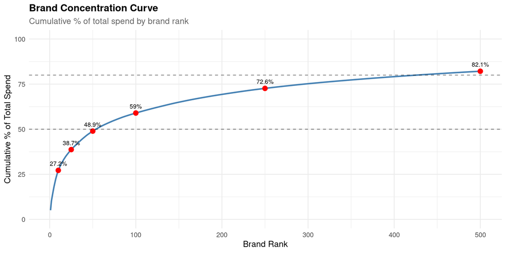

```r
brand_totals[, cumulative_pct := cumsum(Total_Spend) / sum(Total_Spend) * 100]
brand_totals[, rank := .I]

concentration_points <- brand_totals[rank %in% c(10, 25, 50, 100, 250, 500)]

ggplot(brand_totals[rank <= 500], aes(x = rank, y = cumulative_pct)) +
  geom_line(color = "steelblue", linewidth = 1) +
  geom_point(data = concentration_points, color = "red", size = 3) +
  geom_text(data = concentration_points,
            aes(label = paste0(round(cumulative_pct, 1), "%")),
            vjust = -1, hjust = 0.5, size = 3) +
  geom_hline(yintercept = c(50, 80), linetype = "dashed", alpha = 0.5) +
  labs(
    title = "Brand Concentration Curve",
    subtitle = "Cumulative % of total spend by brand rank",
    x = "Brand Rank",
    y = "Cumulative % of Total Spend"
  ) +
  scale_y_continuous(limits = c(0, 100))
```

```r
n_total_brands <- nrow(brand_totals)

if (n_total_brands >= 10) {
  top_10_pct <- brand_totals[rank == 10, cumulative_pct]
  cat("Top 10 brands:", round(top_10_pct, 1), "% of spend\n")
}
```

```
## Top 10 brands: 27.2 % of spend
```

```r
if (n_total_brands >= 50) {
  top_50_pct <- brand_totals[rank == 50, cumulative_pct]
  cat("Top 50 brands:", round(top_50_pct, 1), "% of spend\n")
}
```

```
## Top 50 brands: 48.9 % of spend
```

```r
if (n_total_brands >= 100) {
  top_100_pct <- brand_totals[rank == 100, cumulative_pct]
  cat("Top 100 brands:", round(top_100_pct, 1), "% of spend")
}
```

```
## Top 100 brands: 59 % of spend
```

# 4. Geographic Patterns

## 4.1 Spending by State

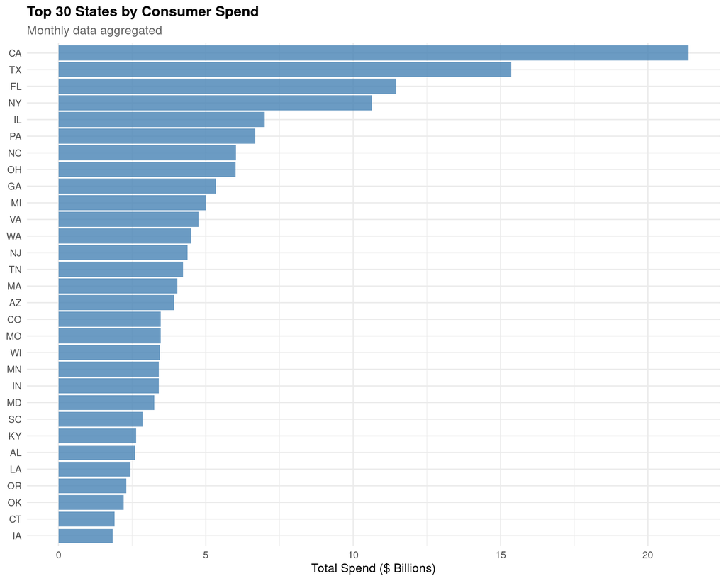

```r
state_spend <- dt[GEO_TYPE == "STATE" & PERIOD_TYPE == "MONTH", .(
  Total_Spend = sum(SPEND_AMOUNT, na.rm = TRUE)
), by = GEO][order(-Total_Spend)]

ggplot(state_spend[1:30], aes(x = reorder(GEO, Total_Spend), y = Total_Spend / 1e9)) +
  geom_col(fill = "steelblue", alpha = 0.8) +
  coord_flip() +
  labs(
    title = "Top 30 States by Consumer Spend",
    subtitle = "Monthly data aggregated",
    x = NULL,
    y = "Total Spend ($ Billions)"
  )
```

## 4.2 Spending by Census Region

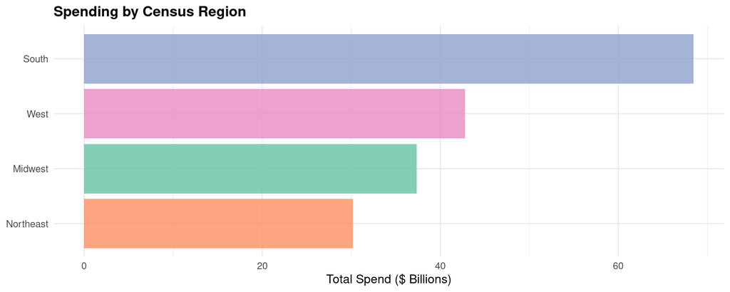

```r
region_spend <- dt[GEO_TYPE == "CENSUS_REGION" & PERIOD_TYPE == "MONTH", .(
  Total_Spend = sum(SPEND_AMOUNT, na.rm = TRUE)
), by = GEO][order(-Total_Spend)]

ggplot(region_spend, aes(x = reorder(GEO, Total_Spend), y = Total_Spend / 1e9, fill = GEO)) +
  geom_col(alpha = 0.8) +
  coord_flip() +
  labs(
    title = "Spending by Census Region",
    x = NULL,
    y = "Total Spend ($ Billions)"
  ) +
  scale_fill_brewer(palette = "Set2", guide = "none")
```

## 4.3 Top CSAs (Metro Areas)

```r
csa_spend <- dt[GEO_TYPE == "CSA" & PERIOD_TYPE == "MONTH", .(
  Total_Spend = sum(SPEND_AMOUNT, na.rm = TRUE),
  N_Brands = uniqueN(BRAND_ID)
), by = GEO][order(-Total_Spend)]

csa_spend[1:25] %>%
  mutate(
    Total_Spend = paste0("$", format(round(Total_Spend / 1e9, 2), big.mark = ","), "B"),
    N_Brands = format(N_Brands, big.mark = ",")
  ) %>%
  kable(caption = "Top 25 CSAs by Consumer Spend") %>%
  kable_styling(bootstrap_options = c("striped", "hover"), full_width = FALSE)
```

Top 25 CSAs by Consumer Spend

| GEO | Total_Spend | N_Brands |
| --- | --- | --- |
| Outside CSA | $36.55B | 12,106 |
| New York-Newark, NY-NJ-CT-PA | $12.27B | 10,938 |
| Los Angeles-Long Beach, CA | $ 8.53B | 11,214 |
| San Jose-San Francisco-Oakland, CA | $ 7.11B | 11,107 |
| Washington-Baltimore-Arlington, DC-MD-VA-WV-PA | $ 5.93B | 10,643 |
| Boston-Worcester-Providence, MA-RI-NH-CT | $ 5.11B | 9,475 |
| Philadelphia-Reading-Camden, PA-NJ-DE-MD | $ 4.89B | 10,343 |
| Chicago-Naperville, IL-IN-WI | $ 4.75B | 9,361 |
| Dallas-Fort Worth, TX-OK | $ 4.37B | 10,487 |
| Atlanta–Athens-Clarke County–Sandy Springs, GA-AL | $ 4.18B | 10,520 |
| Houston-The Woodlands, TX | $ 4.05B | 10,336 |
| Miami-Port St. Lucie-Fort Lauderdale, FL | $ 3.78B | 10,446 |
| Seattle-Tacoma, WA | $ 3.27B | 10,044 |
| Minneapolis-St. Paul, MN-WI | $ 2.96B | 10,615 |
| Phoenix-Mesa, AZ | $ 2.70B | 10,435 |
| Denver-Aurora, CO | $ 2.38B | 10,430 |
| Orlando-Lakeland-Deltona, FL | $ 2.19B | 9,898 |
| Charlotte-Concord, NC-SC | $ 2.09B | 9,858 |
| Detroit-Warren-Ann Arbor, MI | $ 2.08B | 7,884 |
| Portland-Vancouver-Salem, OR-WA | $ 1.97B | 9,688 |
| Sacramento-Roseville, CA | $ 1.82B | 9,823 |
| Nashville-Davidson–Murfreesboro, TN | $ 1.64B | 8,453 |
| Mansfield-Ashland-Bucyrus, OH | $ 1.59B | 5,630 |
| St. Louis-St. Charles-Farmington, MO-IL | $ 1.53B | 7,575 |
| Raleigh-Durham-Cary, NC | $ 1.46B | 9,732 |

# 5. Temporal Trends

## 5.1 National Spending Over Time

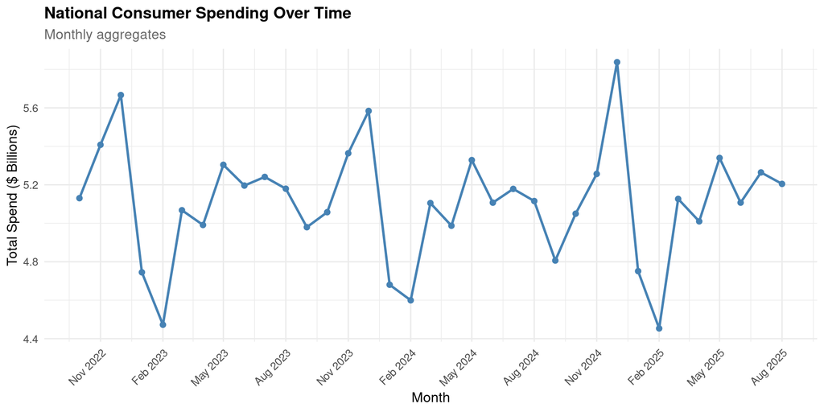

```r
national_monthly <- dt[GEO_TYPE == "TOTAL_US" & PERIOD_TYPE == "MONTH", .(
  Total_Spend = sum(SPEND_AMOUNT, na.rm = TRUE),
  Total_Trans = sum(TRANS_COUNT, na.rm = TRUE),
  N_Brands = uniqueN(BRAND_ID)
), by = .(PERIOD, PERIOD_START_DT)][order(PERIOD_START_DT)]

ggplot(national_monthly, aes(x = PERIOD_START_DT, y = Total_Spend / 1e9)) +
  geom_line(color = "steelblue", linewidth = 1) +
  geom_point(color = "steelblue", size = 2) +
  labs(
    title = "National Consumer Spending Over Time",
    subtitle = "Monthly aggregates",
    x = "Month",
    y = "Total Spend ($ Billions)"
  ) +
  scale_x_date(date_labels = "%b %Y", date_breaks = "3 months") +
  theme(axis.text.x = element_text(angle = 45, hjust = 1))
```

## 5.2 Year-over-Year Growth

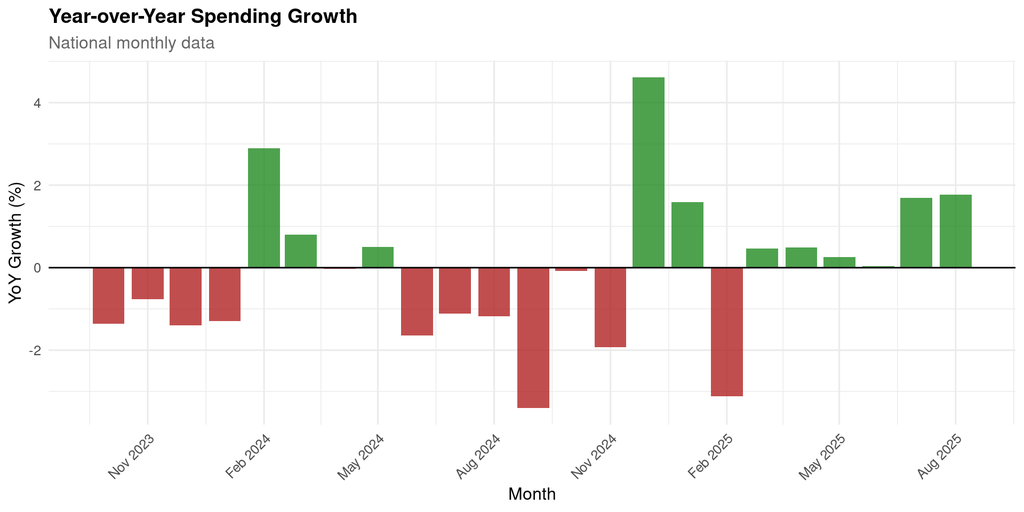

```r
yoy_data <- dt[GEO_TYPE == "TOTAL_US" & PERIOD_TYPE == "MONTH" &
               !is.na(YA_SPEND_AMOUNT) & YA_SPEND_AMOUNT > 0, .(
  Current_Spend = sum(SPEND_AMOUNT, na.rm = TRUE),
  YA_Spend = sum(YA_SPEND_AMOUNT, na.rm = TRUE)
), by = .(PERIOD, PERIOD_START_DT)]

yoy_data[, YoY_Growth := (Current_Spend - YA_Spend) / YA_Spend * 100]

if (nrow(yoy_data) > 0) {
  ggplot(yoy_data, aes(x = PERIOD_START_DT, y = YoY_Growth)) +
    geom_col(aes(fill = YoY_Growth > 0), alpha = 0.8) +
    geom_hline(yintercept = 0, color = "black") +
    labs(
      title = "Year-over-Year Spending Growth",
      subtitle = "National monthly data",
      x = "Month",
      y = "YoY Growth (%)"
    ) +
    scale_fill_manual(values = c("TRUE" = "forestgreen", "FALSE" = "firebrick"), guide = "none") +
    scale_x_date(date_labels = "%b %Y", date_breaks = "3 months") +
    theme(axis.text.x = element_text(angle = 45, hjust = 1))
} else {
  cat("Insufficient YoY data in sample files")
}
```

## 5.3 Quarterly Patterns

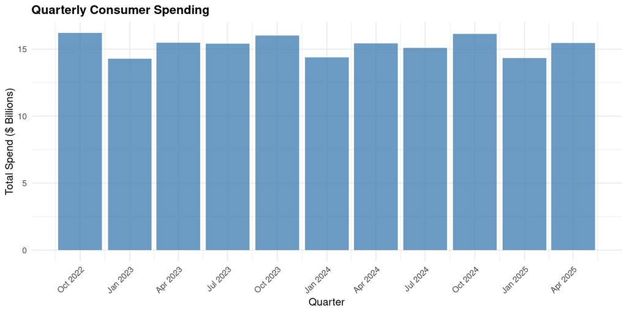

```r
quarterly <- dt[GEO_TYPE == "TOTAL_US" & PERIOD_TYPE == "CAL_QTR", .(
  Total_Spend = sum(SPEND_AMOUNT, na.rm = TRUE)
), by = .(PERIOD, PERIOD_START_DT)][order(PERIOD_START_DT)]

if (nrow(quarterly) > 0) {
  ggplot(quarterly, aes(x = PERIOD_START_DT, y = Total_Spend / 1e9)) +
    geom_col(fill = "steelblue", alpha = 0.8) +
    labs(
      title = "Quarterly Consumer Spending",
      x = "Quarter",
      y = "Total Spend ($ Billions)"
    ) +
    scale_x_date(date_labels = "%b %Y", date_breaks = "3 months") +
    theme(axis.text.x = element_text(angle = 45, hjust = 1))
}
```

# 6. Brand Deep Dives

## 6.1 Top 10 Brands Over Time

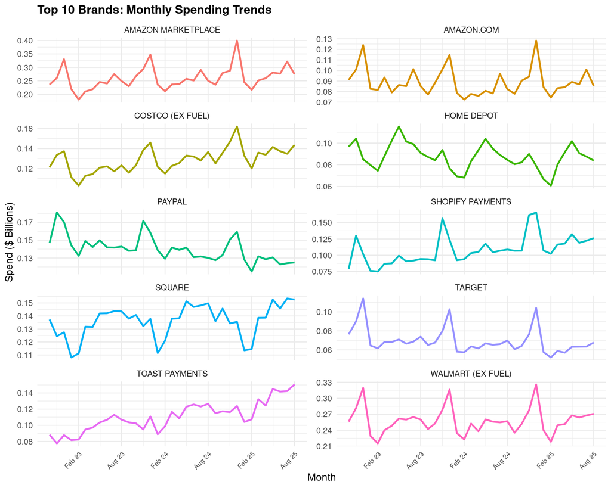

```r
top_10_brands <- brand_totals[1:10, BRAND_NAME]

brand_ts <- dt[BRAND_NAME %in% top_10_brands & GEO_TYPE == "TOTAL_US" & PERIOD_TYPE == "MONTH", .(
  Spend = sum(SPEND_AMOUNT, na.rm = TRUE)
), by = .(BRAND_NAME, PERIOD_START_DT)][order(BRAND_NAME, PERIOD_START_DT)]

ggplot(brand_ts, aes(x = PERIOD_START_DT, y = Spend / 1e9, color = BRAND_NAME)) +
  geom_line(linewidth = 1) +
  facet_wrap(~BRAND_NAME, scales = "free_y", ncol = 2) +
  labs(
    title = "Top 10 Brands: Monthly Spending Trends",
    x = "Month",
    y = "Spend ($ Billions)"
  ) +
  scale_x_date(date_labels = "%b %y", date_breaks = "6 months") +
  theme(
    legend.position = "none",
    axis.text.x = element_text(angle = 45, hjust = 1, size = 8)
  )
```

## 6.2 Brand Geographic Distribution

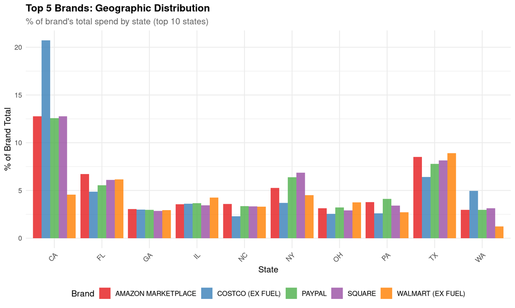

```r
top_5_brands <- brand_totals[1:5, BRAND_NAME]

brand_state <- dt[BRAND_NAME %in% top_5_brands & GEO_TYPE == "STATE" & PERIOD_TYPE == "MONTH", .(
  Total_Spend = sum(SPEND_AMOUNT, na.rm = TRUE)
), by = .(BRAND_NAME, GEO)]

brand_state[, Brand_Total := sum(Total_Spend), by = BRAND_NAME]
brand_state[, Pct_of_Brand := Total_Spend / Brand_Total * 100]

top_states <- brand_state[, .(Total = sum(Total_Spend)), by = GEO][order(-Total)][1:10, GEO]

brand_state[GEO %in% top_states] %>%
  ggplot(aes(x = GEO, y = Pct_of_Brand, fill = BRAND_NAME)) +
  geom_col(position = "dodge", alpha = 0.8) +
  labs(
    title = "Top 5 Brands: Geographic Distribution",
    subtitle = "% of brand's total spend by state (top 10 states)",
    x = "State",
    y = "% of Brand Total",
    fill = "Brand"
  ) +
  scale_fill_brewer(palette = "Set1") +
  theme(axis.text.x = element_text(angle = 45, hjust = 1))
```

# 7. Entity Resolution & Project Oakland Linkage

## 7.1 The Linkage Challenge

To use Consumer Edge data as a dependent variable in Project Oakland, we need to link brands to:

1. **Advan foot traffic data** (via brand names or PLACEKEY)
2. **Politics at Work employee data** (via employer names)

**Challenge:** Brand names may differ across datasets: - Consumer Edge: “MCDONALD’S” - Advan: “McDonald’s”, “McDonalds”, “McDonald’s Restaurant” - Politics at Work: “McDonald’s Corporation”

## 7.2 Brand Name Sample

```r
brand_sample <- dt[, .(N = .N), by = BRAND_NAME][order(-N)][1:50, BRAND_NAME]

data.frame(Brand_Name = brand_sample) %>%
  kable(caption = "Sample Brand Names (Top 50 by frequency)") %>%
  kable_styling(bootstrap_options = c("striped", "hover"), full_width = FALSE) %>%
  scroll_box(height = "400px")
```

Sample Brand Names (Top 50 by frequency)

| Brand_Name |
| --- |
| DOLLAR TREE |
| HULU |
| SHOPIFY PAYMENTS |
| ITUNES |
| SHELL OIL (FUEL) |
| AMAZON PRIME |
| AT&T |
| PEACOCK TV |
| NETFLIX |
| AMAZON.COM |
| WALMART (EX FUEL) |
| SPOTIFY |
| PAYPAL |
| USPS |
| SIRIUS XM |
| AMAZON MARKETPLACE |
| STATE FARM INSURANCE |
| AMAZONVOD |
| SQUARE |
| MCDONALD’S |
| SHIFT4 PAYMENTS |
| TOAST PAYMENTS |
| GOOGLE PAY |
| LOWE’S |
| EBAY |
| CHICK-FIL-A |
| SUBWAY |
| MICROSOFT |
| AUDIBLE.COM |
| BURGER KING |
| TACO BELL |
| PARAMOUNT PLUS |
| DOMINO’S PIZZA |
| WALGREENS |
| DOLLAR GENERAL |
| WENDY’S |
| CVS HEALTH |
| ROKU DISTRIBUTION |
| TARGET |
| VERIZON WIRELESS |
| ETSY |
| STARBUCKS (MERCHANT) |
| HARBOR FREIGHT TOOLS |
| LOVES TRAVEL & COUNTRY STORES (FUEL) |
| TJ MAXX |
| KFC |
| DISH NETWORK |
| HOBBY LOBBY |
| DISNEY PLUS |
| SAM’S CLUB (EX FUEL) |

## 7.3 Proposed Linkage Strategy

### Step 1: Standardize brand names

- Convert to uppercase
- Remove punctuation and extra spaces
- Handle common variations (Corp, Inc, LLC, etc.)

### Step 2: Direct matching

- Exact match after standardization
- High confidence matches

### Step 3: Fuzzy matching

- For remaining unmatched brands
- Use string distance algorithms (Jaro-Winkler, Levenshtein)
- Manual review of close matches

### Step 4: Manual curation

- Industry-specific knowledge for major brands
- Build crosswalk table for repeated use

## 7.4 Research Design Considerations

**As a Dependent Variable:**

| Design | Identification | Data Requirement |
| --- | --- | --- |
| Cross-sectional | Compare aligned vs misaligned firms | Brand-level spending at one point |
| Panel | Within-brand changes over time | Full time series per brand |
| Diff-in-diff | Response to salience shocks (elections, boycotts) | Pre/post event spending |
| Geographic | Same brand, different markets | Brand × geography panel |

**Variation Available:** - **Time:** Q4 2022 - Q2 2025 (covers 2024 election) - **Geography:** State, CSA, region levels - **Granularity:** Monthly, quarterly, rolling periods

## 7.5 Limitations

1. **Panel composition:** Consumer Edge panel may not be representative of all consumers
2. **Brand coverage:** Not all brands in Advan/PaW will appear in Consumer Edge
3. **Aggregation:** Data is brand × geography × time, not POI-level
4. **Selection:** Brands with credit/debit transactions only (excludes cash-heavy businesses)

# 8. Data Reliability Analysis: Brand × CSA × Period Granularity

This section assesses whether the Consumer Edge data has sufficient coverage and variation at the **brand × CSA × time period** level to serve as a reliable dependent variable.

## 8.1 Period Type Detailed Breakdown

```r
period_detail <- dt[, .(
  N_Rows = .N,
  N_Brands = uniqueN(BRAND_ID),
  N_CSAs = uniqueN(GEO[GEO_TYPE == "CSA"]),
  N_Periods = uniqueN(PERIOD),
  Min_Date = min(PERIOD_START_DT, na.rm = TRUE),
  Max_Date = max(PERIOD_END_DT, na.rm = TRUE),
  Total_Spend = sum(SPEND_AMOUNT, na.rm = TRUE)
), by = PERIOD_TYPE][order(-N_Rows)]

period_detail %>%
  mutate(
    N_Rows = format(N_Rows, big.mark = ","),
    N_Brands = format(N_Brands, big.mark = ","),
    N_CSAs = format(N_CSAs, big.mark = ","),
    Total_Spend = paste0("$", format(round(Total_Spend / 1e9, 2), big.mark = ","), "B")
  ) %>%
  kable(caption = "Detailed Period Type Breakdown") %>%
  kable_styling(bootstrap_options = c("striped", "hover"), full_width = FALSE)
```

Detailed Period Type Breakdown

| PERIOD_TYPE | N_Rows | N_Brands | N_CSAs | N_Periods | Min_Date | Max_Date | Total_Spend |
| --- | --- | --- | --- | --- | --- | --- | --- |
| MONTH | 29,610,227 | 12,666 | 173 | 35 | 2022-10-01 | 2025-08-31 | $893.48B |
| DISCRETE_35_DAY | 27,869,210 | 12,681 | 173 | 32 | 2022-09-05 | 2025-09-28 | $936.99B |
| DISCRETE_91_DAY | 12,749,882 | 12,669 | 173 | 12 | 2022-10-03 | 2025-09-28 | $914.04B |
| CAL_QTR | 11,754,952 | 12,654 | 173 | 11 | 2022-10-01 | 2025-06-30 | $841.13B |
| CAL_QTR_JAN | 11,722,789 | 12,626 | 173 | 11 | 2022-11-01 | 2025-07-31 | $841.80B |
| CAL_QTR_FEB | 11,688,724 | 12,615 | 173 | 11 | 2022-12-01 | 2025-08-31 | $840.79B |
| DISCRETE_182_DAY | 7,298,355 | 12,669 | 173 | 6 | 2022-10-03 | 2025-09-28 | $914.04B |
| DISCRETE_364_DAY | 4,156,329 | 12,669 | 173 | 3 | 2022-10-03 | 2025-09-28 | $914.04B |

```r
period_lengths <- dt[, .(
  Period_Days = as.numeric(difftime(PERIOD_END_DT[1], PERIOD_START_DT[1], units = "days"))
), by = .(PERIOD_TYPE, PERIOD)][, .(
  Avg_Days = mean(Period_Days, na.rm = TRUE),
  Min_Days = min(Period_Days, na.rm = TRUE),
  Max_Days = max(Period_Days, na.rm = TRUE)
), by = PERIOD_TYPE]

period_lengths %>%
  kable(caption = "Period Length in Days by Type", digits = 0) %>%
  kable_styling(bootstrap_options = c("striped", "hover"), full_width = FALSE)
```

Period Length in Days by Type

| PERIOD_TYPE | Avg_Days | Min_Days | Max_Days |
| --- | --- | --- | --- |
| CAL_QTR | 90 | 89 | 91 |
| DISCRETE_35_DAY | 34 | 34 | 34 |
| MONTH | 29 | 27 | 30 |
| CAL_QTR_JAN | 90 | 88 | 91 |
| CAL_QTR_FEB | 90 | 89 | 91 |
| DISCRETE_91_DAY | 90 | 90 | 90 |
| DISCRETE_182_DAY | 181 | 181 | 181 |
| DISCRETE_364_DAY | 363 | 363 | 363 |

## 8.2 Top 200 Brands Definition

```r
brand_totals_full <- dt[GEO_TYPE == "TOTAL_US" & PERIOD_TYPE == "MONTH", .(
  Total_Spend = sum(SPEND_AMOUNT, na.rm = TRUE),
  Total_Trans = sum(TRANS_COUNT, na.rm = TRUE),
  Total_Individuals = sum(INDIVIDUAL_COUNT, na.rm = TRUE)
), by = .(BRAND_ID, BRAND_NAME)][order(-Total_Spend)]

top_200_brands <- brand_totals_full[seq_len(min(200, .N))]
top_200_ids <- top_200_brands$BRAND_ID

total_spend_all <- sum(brand_totals_full$Total_Spend)
pct_top_200 <- if(total_spend_all > 0) round(sum(top_200_brands$Total_Spend) / total_spend_all * 100, 1) else NA
cat("Top 200 brands account for", pct_top_200, "% of total national monthly spend\n")
```

```
## Top 200 brands account for 69.3 % of total national monthly spend
```

```r
cat("Brands in top 200:", length(top_200_ids))
```

```
## Brands in top 200: 200
```

## 8.3 CSA Universe

```r
csa_list <- unique(dt[GEO_TYPE == "CSA", GEO])
n_csas <- length(csa_list)

cat("Total unique CSAs in data:", n_csas, "\n\n")
```

```
## Total unique CSAs in data: 173
```

```r
csa_spend <- dt[GEO_TYPE == "CSA" & PERIOD_TYPE == "MONTH", .(
  Total_Spend = sum(SPEND_AMOUNT, na.rm = TRUE),
  N_Brands = uniqueN(BRAND_ID),
  N_Periods = uniqueN(PERIOD)
), by = GEO][order(-Total_Spend)]

csa_spend[1:20] %>%
  mutate(
    Total_Spend = paste0("$", format(round(Total_Spend / 1e9, 2), big.mark = ","), "B"),
    N_Brands = format(N_Brands, big.mark = ",")
  ) %>%
  kable(caption = "Top 20 CSAs by Spend (Monthly Data)") %>%
  kable_styling(bootstrap_options = c("striped", "hover"), full_width = FALSE)
```

Top 20 CSAs by Spend (Monthly Data)

| GEO | Total_Spend | N_Brands | N_Periods |
| --- | --- | --- | --- |
| Outside CSA | $36.55B | 12,106 | 35 |
| New York-Newark, NY-NJ-CT-PA | $12.27B | 10,938 | 35 |
| Los Angeles-Long Beach, CA | $ 8.53B | 11,214 | 35 |
| San Jose-San Francisco-Oakland, CA | $ 7.11B | 11,107 | 35 |
| Washington-Baltimore-Arlington, DC-MD-VA-WV-PA | $ 5.93B | 10,643 | 35 |
| Boston-Worcester-Providence, MA-RI-NH-CT | $ 5.11B | 9,475 | 35 |
| Philadelphia-Reading-Camden, PA-NJ-DE-MD | $ 4.89B | 10,343 | 35 |
| Chicago-Naperville, IL-IN-WI | $ 4.75B | 9,361 | 35 |
| Dallas-Fort Worth, TX-OK | $ 4.37B | 10,487 | 35 |
| Atlanta–Athens-Clarke County–Sandy Springs, GA-AL | $ 4.18B | 10,520 | 35 |
| Houston-The Woodlands, TX | $ 4.05B | 10,336 | 35 |
| Miami-Port St. Lucie-Fort Lauderdale, FL | $ 3.78B | 10,446 | 35 |
| Seattle-Tacoma, WA | $ 3.27B | 10,044 | 35 |
| Minneapolis-St. Paul, MN-WI | $ 2.96B | 10,615 | 35 |
| Phoenix-Mesa, AZ | $ 2.70B | 10,435 | 35 |
| Denver-Aurora, CO | $ 2.38B | 10,430 | 35 |
| Orlando-Lakeland-Deltona, FL | $ 2.19B | 9,898 | 35 |
| Charlotte-Concord, NC-SC | $ 2.09B | 9,858 | 35 |
| Detroit-Warren-Ann Arbor, MI | $ 2.08B | 7,884 | 35 |
| Portland-Vancouver-Salem, OR-WA | $ 1.97B | 9,688 | 35 |

## 8.4 Cell Coverage Analysis: Brand × CSA × Period

```r
dt_csa_monthly <- dt[GEO_TYPE == "CSA" & PERIOD_TYPE == "MONTH" & BRAND_ID %in% top_200_ids]

unique_periods <- uniqueN(dt_csa_monthly$PERIOD)
unique_csas <- uniqueN(dt_csa_monthly$GEO)
unique_brands_in_csa <- uniqueN(dt_csa_monthly$BRAND_ID)

theoretical_cells <- unique_brands_in_csa * unique_csas * unique_periods
actual_cells <- nrow(dt_csa_monthly)

cell_coverage <- dt_csa_monthly[, .(
  N_Cells = .N,
  N_Periods = uniqueN(PERIOD),
  N_CSAs = uniqueN(GEO)
), by = BRAND_ID]

cell_coverage <- merge(cell_coverage, top_200_brands[, .(BRAND_ID, BRAND_NAME, Total_Spend)], by = "BRAND_ID")

cat("For Top 200 Brands × CSA × Monthly:\n")
```

```
## For Top 200 Brands × CSA × Monthly:
```

```r
cat("- Unique brands appearing in CSA data:", unique_brands_in_csa, "\n")
```

```
## - Unique brands appearing in CSA data: 200
```

```r
cat("- Unique CSAs:", unique_csas, "\n")
```

```
## - Unique CSAs: 173
```

```r
cat("- Unique periods:", unique_periods, "\n")
```

```
## - Unique periods: 35
```

```r
cat("- Theoretical maximum cells (brand × CSA × period):", format(theoretical_cells, big.mark = ","), "\n")
```

```
## - Theoretical maximum cells (brand × CSA × period): 1,211,000
```

```r
cat("- Actual cells with data:", format(actual_cells, big.mark = ","), "\n")
```

```
## - Actual cells with data: 1,127,681
```

```r
fill_rate <- if(theoretical_cells > 0) round(actual_cells / theoretical_cells * 100, 1) else 0
cat("- Overall fill rate:", fill_rate, "%\n")
```

```
## - Overall fill rate: 93.1 %
```

## 8.5 Cell Size Distribution

How many observations (rows) exist per brand × CSA combination?

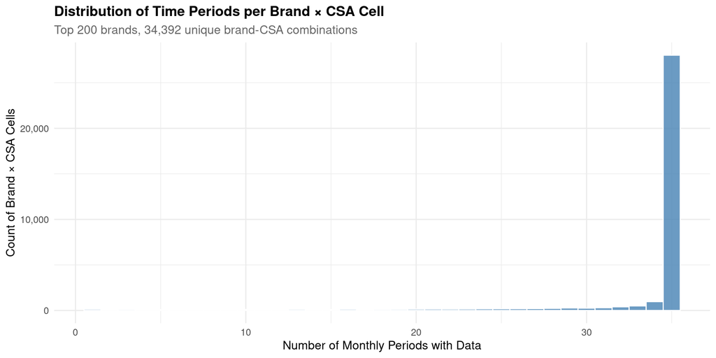

```r
brand_csa_cells <- dt_csa_monthly[, .(
  N_Periods = .N,
  Total_Spend = sum(SPEND_AMOUNT, na.rm = TRUE),
  Avg_Spend = mean(SPEND_AMOUNT, na.rm = TRUE)
), by = .(BRAND_ID, GEO)]

brand_csa_cells <- merge(brand_csa_cells,
                         top_200_brands[, .(BRAND_ID, BRAND_NAME)],
                         by = "BRAND_ID")

ggplot(brand_csa_cells, aes(x = N_Periods)) +
  geom_histogram(binwidth = 1, fill = "steelblue", color = "white", alpha = 0.8) +
  labs(
    title = "Distribution of Time Periods per Brand × CSA Cell",
    subtitle = paste("Top 200 brands,", format(nrow(brand_csa_cells), big.mark = ","), "unique brand-CSA combinations"),
    x = "Number of Monthly Periods with Data",
    y = "Count of Brand × CSA Cells"
  ) +
  scale_y_continuous(labels = comma)
```

```r
cell_size_stats <- brand_csa_cells[, .(
  Min = min(N_Periods),
  P10 = quantile(N_Periods, 0.10),
  P25 = quantile(N_Periods, 0.25),
  Median = median(N_Periods),
  P75 = quantile(N_Periods, 0.75),
  P90 = quantile(N_Periods, 0.90),
  Max = max(N_Periods)
)]

cell_size_stats %>%
  kable(caption = "Distribution of Periods per Brand × CSA Cell", digits = 0) %>%
  kable_styling(bootstrap_options = c("striped", "hover"), full_width = FALSE)
```

Distribution of Periods per Brand × CSA Cell

| Min | P10 | P25 | Median | P75 | P90 | Max |
| --- | --- | --- | --- | --- | --- | --- |
| 1 | 27 | 35 | 35 | 35 | 35 | 35 |

## 8.6 Brand-Level CSA Coverage

How many CSAs does each top brand appear in?

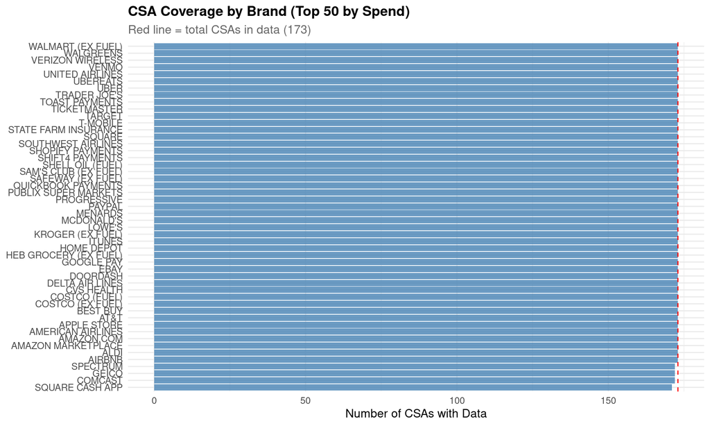

```r
brand_coverage <- brand_csa_cells[, .(
  N_CSAs = uniqueN(GEO),
  N_Total_Periods = sum(N_Periods),
  Total_Spend = sum(Total_Spend)
), by = .(BRAND_ID, BRAND_NAME)][order(-Total_Spend)]

ggplot(brand_coverage[1:50], aes(x = reorder(BRAND_NAME, N_CSAs), y = N_CSAs)) +
  geom_col(fill = "steelblue", alpha = 0.8) +
  geom_hline(yintercept = unique_csas, linetype = "dashed", color = "red") +
  coord_flip() +
  labs(
    title = "CSA Coverage by Brand (Top 50 by Spend)",
    subtitle = paste("Red line = total CSAs in data (", unique_csas, ")", sep = ""),
    x = NULL,
    y = "Number of CSAs with Data"
  )
```

```r
brand_coverage[1:30] %>%
  mutate(
    Pct_CSA_Coverage = paste0(round(N_CSAs / max(unique_csas, 1) * 100, 1), "%"),
    Total_Spend = paste0("$", format(round(Total_Spend / 1e9, 2), big.mark = ","), "B")
  ) %>%
  select(BRAND_NAME, N_CSAs, Pct_CSA_Coverage, N_Total_Periods, Total_Spend) %>%
  kable(caption = "Top 30 Brands: CSA Coverage Summary") %>%
  kable_styling(bootstrap_options = c("striped", "hover"), full_width = FALSE)
```

Top 30 Brands: CSA Coverage Summary

| BRAND_NAME | N_CSAs | Pct_CSA_Coverage | N_Total_Periods | Total_Spend |
| --- | --- | --- | --- | --- |
| AMAZON MARKETPLACE | 173 | 100% | 6055 | $9.10B |
| WALMART (EX FUEL) | 173 | 100% | 6055 | $9.02B |
| PAYPAL | 173 | 100% | 6055 | $4.91B |
| SQUARE | 173 | 100% | 6055 | $4.76B |
| COSTCO (EX FUEL) | 173 | 100% | 6022 | $4.51B |
| TOAST PAYMENTS | 173 | 100% | 6055 | $3.88B |
| SHOPIFY PAYMENTS | 173 | 100% | 6055 | $3.80B |
| AMAZON.COM | 173 | 100% | 6055 | $3.11B |
| HOME DEPOT | 173 | 100% | 6033 | $3.06B |
| TARGET | 173 | 100% | 6047 | $2.44B |
| SHIFT4 PAYMENTS | 173 | 100% | 6055 | $2.04B |
| LOWE’S | 173 | 100% | 6054 | $1.92B |
| AT&T | 173 | 100% | 6055 | $1.67B |
| SAM’S CLUB (EX FUEL) | 173 | 100% | 6040 | $1.65B |
| STATE FARM INSURANCE | 173 | 100% | 6055 | $1.55B |
| AIRBNB | 173 | 100% | 5967 | $1.49B |
| KROGER (EX FUEL) | 173 | 100% | 5940 | $1.38B |
| PUBLIX SUPER MARKETS | 173 | 100% | 5958 | $1.31B |
| QUICKBOOK PAYMENTS | 173 | 100% | 6034 | $1.25B |
| EBAY | 173 | 100% | 6054 | $1.13B |
| ITUNES | 173 | 100% | 6055 | $1.09B |
| DOORDASH | 173 | 100% | 6039 | $1.09B |
| AMERICAN AIRLINES | 173 | 100% | 5978 | $1.05B |
| PROGRESSIVE | 173 | 100% | 5991 | $1.02B |
| UNITED AIRLINES | 173 | 100% | 5899 | $0.93B |
| BEST BUY | 173 | 100% | 5952 | $0.91B |
| DELTA AIR LINES | 173 | 100% | 5898 | $0.90B |
| GEICO | 172 | 99.4% | 5936 | $0.84B |
| T-MOBILE | 173 | 100% | 5987 | $0.83B |
| SPECTRUM | 172 | 99.4% | 5899 | $0.83B |

## 8.7 Coefficient of Variation Analysis

How variable is spending **within** each brand × CSA over time?

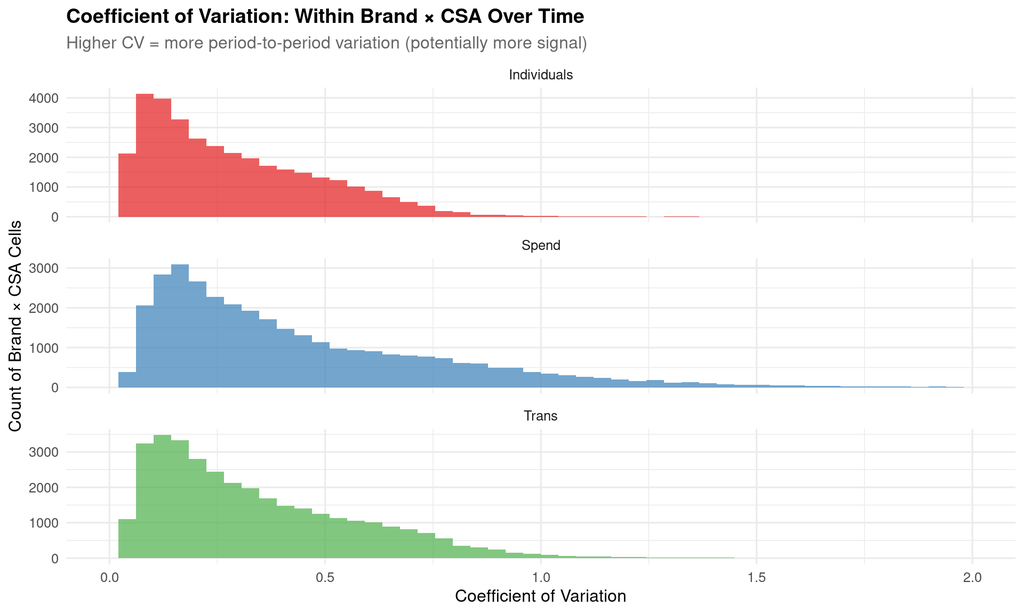

```r
cv_analysis <- dt_csa_monthly[, .(
  N_Periods = .N,
  Mean_Spend = mean(SPEND_AMOUNT, na.rm = TRUE),
  SD_Spend = sd(SPEND_AMOUNT, na.rm = TRUE),
  Mean_Trans = mean(TRANS_COUNT, na.rm = TRUE),
  SD_Trans = sd(TRANS_COUNT, na.rm = TRUE),
  Mean_Individuals = mean(INDIVIDUAL_COUNT, na.rm = TRUE),
  SD_Individuals = sd(INDIVIDUAL_COUNT, na.rm = TRUE)
), by = .(BRAND_ID, GEO)]

cv_analysis[N_Periods >= 2 & Mean_Spend > 0, CV_Spend := SD_Spend / Mean_Spend]
cv_analysis[N_Periods >= 2 & Mean_Trans > 0, CV_Trans := SD_Trans / Mean_Trans]
cv_analysis[N_Periods >= 2 & Mean_Individuals > 0, CV_Individuals := SD_Individuals / Mean_Individuals]

cv_analysis <- merge(cv_analysis, top_200_brands[, .(BRAND_ID, BRAND_NAME)], by = "BRAND_ID")

cv_long <- melt(cv_analysis[N_Periods >= 2],
                id.vars = c("BRAND_ID", "BRAND_NAME", "GEO", "N_Periods"),
                measure.vars = c("CV_Spend", "CV_Trans", "CV_Individuals"),
                variable.name = "Metric", value.name = "CV")

cv_long[, Metric := gsub("CV_", "", Metric)]

ggplot(cv_long[!is.na(CV) & is.finite(CV)], aes(x = CV, fill = Metric)) +
  geom_histogram(bins = 50, alpha = 0.7, position = "identity") +
  facet_wrap(~Metric, scales = "free_y", ncol = 1) +
  labs(
    title = "Coefficient of Variation: Within Brand × CSA Over Time",
    subtitle = "Higher CV = more period-to-period variation (potentially more signal)",
    x = "Coefficient of Variation",
    y = "Count of Brand × CSA Cells"
  ) +
  scale_fill_brewer(palette = "Set1", guide = "none") +
  xlim(0, 2)
```

```r
cv_summary <- cv_long[!is.na(CV) & is.finite(CV), .(
  Min = min(CV),
  P10 = quantile(CV, 0.10),
  P25 = quantile(CV, 0.25),
  Median = median(CV),
  P75 = quantile(CV, 0.75),
  P90 = quantile(CV, 0.90),
  Max = min(max(CV), 10)
), by = Metric]

cv_summary %>%
  kable(caption = "CV Distribution by Metric (capped at 10)", digits = 3) %>%
  kable_styling(bootstrap_options = c("striped", "hover"), full_width = FALSE)
```

CV Distribution by Metric (capped at 10)

| Metric | Min | P10 | P25 | Median | P75 | P90 | Max |
| --- | --- | --- | --- | --- | --- | --- | --- |
| Spend | 0.007 | 0.117 | 0.186 | 0.343 | 0.629 | 0.936 | 4.797 |
| Trans | 0.000 | 0.090 | 0.150 | 0.277 | 0.487 | 0.689 | 4.084 |
| Individuals | 0.000 | 0.071 | 0.123 | 0.237 | 0.415 | 0.574 | 2.030 |

## 8.8 Period-over-Period Variation

What’s the typical month-over-month % change in spending?

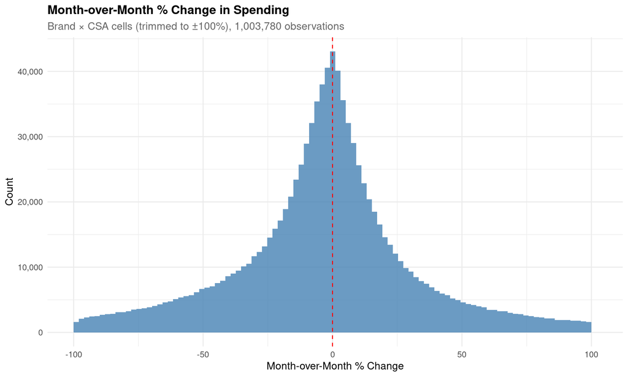

```r
dt_csa_monthly_sorted <- dt_csa_monthly[order(BRAND_ID, GEO, PERIOD_START_DT)]

dt_csa_monthly_sorted[, `:=`(
  Prev_Spend = shift(SPEND_AMOUNT, 1),
  Prev_Trans = shift(TRANS_COUNT, 1),
  Prev_Individuals = shift(INDIVIDUAL_COUNT, 1)
), by = .(BRAND_ID, GEO)]

dt_csa_monthly_sorted[Prev_Spend > 0, MoM_Spend_Pct := (SPEND_AMOUNT - Prev_Spend) / Prev_Spend * 100]
dt_csa_monthly_sorted[Prev_Trans > 0, MoM_Trans_Pct := (TRANS_COUNT - Prev_Trans) / Prev_Trans * 100]
dt_csa_monthly_sorted[Prev_Individuals > 0, MoM_Individuals_Pct := (INDIVIDUAL_COUNT - Prev_Individuals) / Prev_Individuals * 100]

mom_valid <- dt_csa_monthly_sorted[!is.na(MoM_Spend_Pct)]

ggplot(mom_valid[abs(MoM_Spend_Pct) <= 100], aes(x = MoM_Spend_Pct)) +
  geom_histogram(bins = 100, fill = "steelblue", alpha = 0.8) +
  geom_vline(xintercept = 0, color = "red", linetype = "dashed") +
  labs(
    title = "Month-over-Month % Change in Spending",
    subtitle = paste("Brand × CSA cells (trimmed to ±100%),", format(nrow(mom_valid[abs(MoM_Spend_Pct) <= 100]), big.mark = ","), "observations"),
    x = "Month-over-Month % Change",
    y = "Count"
  ) +
  scale_y_continuous(labels = comma)
```

```r
mom_summary <- mom_valid[, .(
  N_Obs = .N,
  P5 = quantile(MoM_Spend_Pct, 0.05, na.rm = TRUE),
  P10 = quantile(MoM_Spend_Pct, 0.10, na.rm = TRUE),
  P25 = quantile(MoM_Spend_Pct, 0.25, na.rm = TRUE),
  Median = median(MoM_Spend_Pct, na.rm = TRUE),
  P75 = quantile(MoM_Spend_Pct, 0.75, na.rm = TRUE),
  P90 = quantile(MoM_Spend_Pct, 0.90, na.rm = TRUE),
  P95 = quantile(MoM_Spend_Pct, 0.95, na.rm = TRUE)
)]

mom_summary %>%
  mutate(N_Obs = format(N_Obs, big.mark = ",")) %>%
  kable(caption = "Month-over-Month Spend % Change Distribution", digits = 1) %>%
  kable_styling(bootstrap_options = c("striped", "hover"), full_width = FALSE)
```

Month-over-Month Spend % Change Distribution

| N_Obs | P5 | P10 | P25 | Median | P75 | P90 | P95 |
| --- | --- | --- | --- | --- | --- | --- | --- |
| 1,093,289 | -64.3 | -45.5 | -17.5 | 0.2 | 21.3 | 79.3 | 172.7 |

## 8.9 Sparsity Heat Map: Top Brands × Top CSAs

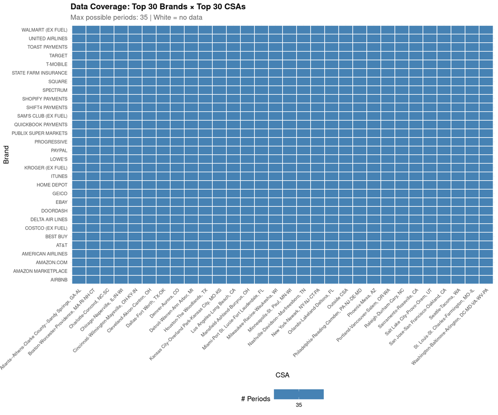

```r
top_30_brands_ids <- brand_coverage[1:30, BRAND_ID]
top_30_csas <- csa_spend[1:30, GEO]

heatmap_data <- dt_csa_monthly[BRAND_ID %in% top_30_brands_ids & GEO %in% top_30_csas, .(
  N_Periods = uniqueN(PERIOD),
  Total_Spend = sum(SPEND_AMOUNT, na.rm = TRUE)
), by = .(BRAND_ID, GEO)]

heatmap_data <- merge(heatmap_data, top_200_brands[, .(BRAND_ID, BRAND_NAME)], by = "BRAND_ID")

heatmap_complete <- CJ(BRAND_NAME = brand_coverage[BRAND_ID %in% top_30_brands_ids, BRAND_NAME],
                       GEO = top_30_csas)
heatmap_complete <- merge(heatmap_complete, heatmap_data[, .(BRAND_NAME, GEO, N_Periods)],
                          by = c("BRAND_NAME", "GEO"), all.x = TRUE)
heatmap_complete[is.na(N_Periods), N_Periods := 0]

ggplot(heatmap_complete, aes(x = GEO, y = BRAND_NAME, fill = N_Periods)) +
  geom_tile(color = "white", linewidth = 0.5) +
  scale_fill_gradient2(low = "white", mid = "steelblue", high = "darkblue",
                       midpoint = unique_periods / 2,
                       name = "# Periods") +
  labs(
    title = "Data Coverage: Top 30 Brands × Top 30 CSAs",
    subtitle = paste("Max possible periods:", unique_periods, "| White = no data"),
    x = "CSA",
    y = "Brand"
  ) +
  theme(
    axis.text.x = element_text(angle = 45, hjust = 1, size = 8),
    axis.text.y = element_text(size = 8)
  )
```

## 8.10 Reliability Summary Statistics

```r
reliability_stats <- list(
  "Total Brand × CSA × Period cells" = format(nrow(dt_csa_monthly), big.mark = ","),
  "Unique brand × CSA combinations" = format(nrow(brand_csa_cells), big.mark = ","),
  "Median periods per brand × CSA" = cell_size_stats$Median,
  "Brand × CSA cells with 6+ periods" = paste0(
    format(sum(brand_csa_cells$N_Periods >= 6), big.mark = ","),
    " (", round(mean(brand_csa_cells$N_Periods >= 6) * 100, 1), "%)"
  ),
  "Brand × CSA cells with 12+ periods" = paste0(
    format(sum(brand_csa_cells$N_Periods >= 12), big.mark = ","),
    " (", round(mean(brand_csa_cells$N_Periods >= 12) * 100, 1), "%)"
  ),
  "Median CV of spending (within brand × CSA)" = round(cv_summary[Metric == "Spend", Median], 3),
  "Median MoM % change" = paste0(round(mom_summary$Median, 1), "%"),
  "IQR of MoM % change" = paste0(round(mom_summary$P25, 1), "% to ", round(mom_summary$P75, 1), "%")
)

data.frame(
  Metric = names(reliability_stats),
  Value = unlist(reliability_stats)
) %>%
  kable(caption = "Reliability Summary: Brand × CSA × Period Level") %>%
  kable_styling(bootstrap_options = c("striped", "hover"), full_width = FALSE)
```

Reliability Summary: Brand × CSA × Period Level

|  | Metric | Value |
| --- | --- | --- |
| Total Brand × CSA × Period cells | Total Brand × CSA × Period cells | 1,127,681 |
| Unique brand × CSA combinations | Unique brand × CSA combinations | 34,392 |
| Median periods per brand × CSA | Median periods per brand × CSA | 35 |
| Brand × CSA cells with 6+ periods | Brand × CSA cells with 6+ periods | 33,835 (98.4%) |
| Brand × CSA cells with 12+ periods | Brand × CSA cells with 12+ periods | 33,227 (96.6%) |
| Median CV of spending (within brand × CSA) | Median CV of spending (within brand × CSA) | 0.343 |
| Median MoM % change | Median MoM % change | 0.2% |
| IQR of MoM % change | IQR of MoM % change | -17.5% to 21.3% |

# 9. Summary & Next Steps

## Recommended Next Steps

# Appendix

## A.2 Data File List

```r
data.frame(File = basename(files)) %>%
  kable(caption = paste("All", n_total_files, "Data Files")) %>%
  kable_styling(bootstrap_options = c("striped", "hover"), full_width = FALSE) %>%
  scroll_box(height = "300px")
```

All 64 Data Files

| File |
| --- |
| brand-and-geography-cohort-breakout-usa-1_0_0_0.csv.gz |
| brand-and-geography-cohort-breakout-usa-1_0_1_0.csv.gz |
| brand-and-geography-cohort-breakout-usa-1_0_2_0.csv.gz |
| brand-and-geography-cohort-breakout-usa-1_0_3_0.csv.gz |
| brand-and-geography-cohort-breakout-usa-1_0_4_0.csv.gz |
| brand-and-geography-cohort-breakout-usa-1_0_5_0.csv.gz |
| brand-and-geography-cohort-breakout-usa-1_0_6_0.csv.gz |
| brand-and-geography-cohort-breakout-usa-1_0_7_0.csv.gz |
| brand-and-geography-cohort-breakout-usa-1_1_0_0.csv.gz |
| brand-and-geography-cohort-breakout-usa-1_1_1_0.csv.gz |
| brand-and-geography-cohort-breakout-usa-1_1_2_0.csv.gz |
| brand-and-geography-cohort-breakout-usa-1_1_3_0.csv.gz |
| brand-and-geography-cohort-breakout-usa-1_1_4_0.csv.gz |
| brand-and-geography-cohort-breakout-usa-1_1_5_0.csv.gz |
| brand-and-geography-cohort-breakout-usa-1_1_6_0.csv.gz |
| brand-and-geography-cohort-breakout-usa-1_1_7_0.csv.gz |
| brand-and-geography-cohort-breakout-usa-1_2_0_0.csv.gz |
| brand-and-geography-cohort-breakout-usa-1_2_1_0.csv.gz |
| brand-and-geography-cohort-breakout-usa-1_2_2_0.csv.gz |
| brand-and-geography-cohort-breakout-usa-1_2_3_0.csv.gz |
| brand-and-geography-cohort-breakout-usa-1_2_4_0.csv.gz |
| brand-and-geography-cohort-breakout-usa-1_2_5_0.csv.gz |
| brand-and-geography-cohort-breakout-usa-1_2_6_0.csv.gz |
| brand-and-geography-cohort-breakout-usa-1_2_7_0.csv.gz |
| brand-and-geography-cohort-breakout-usa-1_3_0_0.csv.gz |
| brand-and-geography-cohort-breakout-usa-1_3_1_0.csv.gz |
| brand-and-geography-cohort-breakout-usa-1_3_2_0.csv.gz |
| brand-and-geography-cohort-breakout-usa-1_3_3_0.csv.gz |
| brand-and-geography-cohort-breakout-usa-1_3_4_0.csv.gz |
| brand-and-geography-cohort-breakout-usa-1_3_5_0.csv.gz |
| brand-and-geography-cohort-breakout-usa-1_3_6_0.csv.gz |
| brand-and-geography-cohort-breakout-usa-1_3_7_0.csv.gz |
| brand-and-geography-cohort-breakout-usa-1_4_0_0.csv.gz |
| brand-and-geography-cohort-breakout-usa-1_4_1_0.csv.gz |
| brand-and-geography-cohort-breakout-usa-1_4_2_0.csv.gz |
| brand-and-geography-cohort-breakout-usa-1_4_3_0.csv.gz |
| brand-and-geography-cohort-breakout-usa-1_4_4_0.csv.gz |
| brand-and-geography-cohort-breakout-usa-1_4_5_0.csv.gz |
| brand-and-geography-cohort-breakout-usa-1_4_6_0.csv.gz |
| brand-and-geography-cohort-breakout-usa-1_4_7_0.csv.gz |
| brand-and-geography-cohort-breakout-usa-1_5_0_0.csv.gz |
| brand-and-geography-cohort-breakout-usa-1_5_1_0.csv.gz |
| brand-and-geography-cohort-breakout-usa-1_5_2_0.csv.gz |
| brand-and-geography-cohort-breakout-usa-1_5_3_0.csv.gz |
| brand-and-geography-cohort-breakout-usa-1_5_4_0.csv.gz |
| brand-and-geography-cohort-breakout-usa-1_5_5_0.csv.gz |
| brand-and-geography-cohort-breakout-usa-1_5_6_0.csv.gz |
| brand-and-geography-cohort-breakout-usa-1_5_7_0.csv.gz |
| brand-and-geography-cohort-breakout-usa-1_6_0_0.csv.gz |
| brand-and-geography-cohort-breakout-usa-1_6_1_0.csv.gz |
| brand-and-geography-cohort-breakout-usa-1_6_2_0.csv.gz |
| brand-and-geography-cohort-breakout-usa-1_6_3_0.csv.gz |
| brand-and-geography-cohort-breakout-usa-1_6_4_0.csv.gz |
| brand-and-geography-cohort-breakout-usa-1_6_5_0.csv.gz |
| brand-and-geography-cohort-breakout-usa-1_6_6_0.csv.gz |
| brand-and-geography-cohort-breakout-usa-1_6_7_0.csv.gz |
| brand-and-geography-cohort-breakout-usa-1_7_0_0.csv.gz |
| brand-and-geography-cohort-breakout-usa-1_7_1_0.csv.gz |
| brand-and-geography-cohort-breakout-usa-1_7_2_0.csv.gz |
| brand-and-geography-cohort-breakout-usa-1_7_3_0.csv.gz |
| brand-and-geography-cohort-breakout-usa-1_7_4_0.csv.gz |
| brand-and-geography-cohort-breakout-usa-1_7_5_0.csv.gz |
| brand-and-geography-cohort-breakout-usa-1_7_6_0.csv.gz |
| brand-and-geography-cohort-breakout-usa-1_7_7_0.csv.gz |

*Report generated: 2026-01-12 12:07:59.847622*

*Data source: Consumer Edge “Brand and Geography Cohort Breakout USA 1” via Dewey Data*